# Homework 1

## Descriptive statistics for transitions

Define S and Q datasets:

```r
s = transitions[transitions$dialActA == 'statement',]
q = transitions[transitions$dialActA == 'yn_q',]
```

Look at S’s first 6 data points:

```r
head_s = head(s, 6)
kable(head_s)
```

|  | id | time | file | dur | spkA | sexA | dobA | dialA | spkB | sexB | dobB | dialB | ftotype | dialActA | dialActDurA | turnDurA | dialActB | dialActDurB | turnDurB | uttA | uttStartA | uttEndA | uttDurA | uttNPhonA | uttNSylA | uttPosA | uttB | uttStartB | uttEndB | … |
| --- | --- | --- | --- | --- | --- | --- | --- | --- | --- | --- | --- | --- | --- | --- | --- | --- | --- | --- | --- | --- | --- | --- | --- | --- | --- | --- | --- | --- | --- | --- |
| 1 | 0 | 22284 | sw3154.eaf | 323 | spkr1290 | F | 1952 | NORTHERN | spkr1288 | M | 1946 | NORTH | G21_B__utt_A__utt | statement | 5108 | 10618 | yn_q | 6649 | 6649 | whatever_p[lastics]-_other_plastics_are_acceptable | 20173 | 22283 | 2110 | 30 | 13 | WDT_NNS_JJ_NNS_VBP_JJ | are_are_you_in_the_part_of_town_where_uh_they_have_gotten_into_the | 22607 | 26116 | … |
| 4 | 3 | 43168 | sw3154.eaf | 333 | spkr1288 | M | 1946 | NORTH | spkr1290 | F | 1952 | NORTHERN | G12_A__utt_B__utt | statement | 8260 | 10720 | backchannel | 390 | 7590 | was_waiting_for_the_delivery_of_whatever_those_containers_were | 40157 | 43167 | 3010 | 41 | 18 | VBD_VBG_IN_DT_NN_IN_WP_DT_NNS_VBD | right_well_no_i_haven't_seen_any_so_i_i_thought_that_it_all_had_all_been_delayed_several_times_so_i_have_no_idea_what_they_look_like_and_i'm | 43501 | 51091 | … |
| 5 | 4 | 53225 | sw3154.eaf | 149 | spkr1290 | F | 1952 | NORTHERN | spkr1288 | M | 1946 | NORTH | G21_B__utt_A__utt | statement | 1530 | 1530 | opinion | 9103 | 17212 | kind_of_anxious_to_see_them | 51694 | 53224 | 1530 | 19 | 7 | RB_RB_JJ_TO_VB_PRP | that's_going_to_be_interesting_because_it's_uh | 53374 | 55317 | … |
| 8 | 7 | 104177 | sw3154.eaf | 623 | spkr1288 | M | 1946 | NORTH | spkr1290 | F | 1952 | NORTHERN | G12_A__utt_B__utt | statement | 10941 | 16851 | backchannel | 370 | 370 | hey_the_farmers_brought_their_eggs_to_town_and_the_local_hatchery | 101072 | 104176 | 3104 | 41 | 16 | UH_DT_NNS_VBD_PRP$_NNS_IN_NN_CC_DT_JJ_NN | right | 104800 | 105170 | … |
| 10 | 9 | 117470 | sw3154.eaf | 289 | spkr1288 | M | 1946 | NORTH | spkr1290 | F | 1952 | NORTHERN | G12_A__utt_B__utt | statement | 12272 | 12272 | backchannel | 316 | 316 | the_recycling_going_on_then_that_we_should_have_now | 114389 | 117469 | 3080 | 33 | 14 | DT_NN_VBG_IN_RB_WDT_PRP_MD_VB_RB | right | 117759 | 118075 | … |
| 12 | 11 | 129415 | sw3154.eaf | 470 | spkr1288 | M | 1946 | NORTH | spkr1290 | F | 1952 | NORTHERN | G12_A__utt_B__utt | statement | 1518 | 1518 | agree | 1570 | 5060 | all_had_a_deposit_on_them | 127896 | 129414 | 1518 | 18 | 8 | DT_VBD_DT_NN_IN_PRP | oh_of_course_that_they_did_you_know_actually_we_had_milk_delivered_to_our_house | 129885 | 134945 | … |

Calculate S’s mean transition duration:

```r
s_mean_trans_dur = mean(s$dur, na.rm = TRUE)
s_mean_trans_dur
```

```
## [1] 196.6751
```

Calculate S’s transition duration standard deviation:

```r
s_sd_trans_dur = sd(s$dur, na.rm = TRUE)
s_sd_trans_dur
```

```
## [1] 476.619
```

Calculate S’s number of observations:

```r
s_nrow = nrow(s)
s_nrow
```

```
## [1] 7072
```

Calculate S’s transition duration standard error:

```r
s_se_trans_dur = s_sd_trans_dur/sqrt(s_nrow)
s_se_trans_dur
```

```
## [1] 5.667614
```

Calculate S’s 95% confidence interval

```r
s_conf_interval = list(s_mean_trans_dur- s_se_trans_dur*2, s_mean_trans_dur+ s_se_trans_dur*2)
s_conf_interval
```

```
## [[1]]
## [1] 185.3399
##
## [[2]]
## [1] 208.0103
```

Look at Q’s first 6 data points:

```r
head_q = head(q, 6)
kable(head_q)
```

|  | id | time | file | dur | spkA | sexA | dobA | dialA | spkB | sexB | dobB | dialB | ftotype | dialActA | dialActDurA | turnDurA | dialActB | dialActDurB | turnDurB | uttA | uttStartA | uttEndA | uttDurA | uttNPhonA | uttNSylA | uttPosA | uttB | uttStartB | uttEndB | … |
| --- | --- | --- | --- | --- | --- | --- | --- | --- | --- | --- | --- | --- | --- | --- | --- | --- | --- | --- | --- | --- | --- | --- | --- | --- | --- | --- | --- | --- | --- | --- |
| 2 | 1 | 29257 | sw3154.eaf | 250 | spkr1288 | M | 1946 | NORTH | spkr1290 | F | 1952 | NORTHERN | G12_A__utt_B__utt | yn_q | 6649 | 6649 | no | 603 | 2840 | other_containers_yet_for_recycling | 27236 | 29256 | 2020 | 25 | 11 | JJ_NNS_CC_IN_NN | no_no_i_didn't_think_that_anybody_had_those_at_all_yet | 29507 | 32347 | … |
| 34 | 33 | 281107 | sw3154.eaf | 3 | spkr1288 | M | 1946 | NORTH | spkr1290 | F | 1952 | NORTHERN | G12_A__utt_B__utt | yn_q | 1490 | 1490 | affirm | 2432 | 2432 | they're_back_to_glass_you're_saying | 279616 | 281106 | 1490 | 19 | 7 | RB_IN_NN_VBG | they_were_glass_they_were_the_glass_uh | 281110 | 283542 | … |
| 64 | 63 | 43408 | sw3155.eaf | -178 | spkr1351 | F | 1955 | SOUTH | spkr1361 | F | 1966 | WESTERN | O12_A__utt_B__utt | yn_q | 1322 | 3467 | yes | 627 | 4029 | yeah_[laughter-right]_yeah_he_maims_them_1_pretty_good_doesn't_he | 40118 | 43585 | 3467 | 30 | 12 | UH_UH_UH_PRP_VBZ_PRP_RB_JJ_PRP | um-hum_he_he | 43408 | 44499 | … |
| 95 | 94 | 112921 | sw3155.eaf | 29 | spkr1361 | F | 1966 | WESTERN | spkr1351 | F | 1955 | SOUTH | G21_B__utt_A__utt | yn_q | 480 | 480 | yes | 256 | 256 | did_she | 112440 | 112920 | 480 | 5 | 2 | VBD_PRP | yeah | 112950 | 113206 | … |
| 113 | 112 | 160306 | sw3155.eaf | 55 | spkr1361 | F | 1966 | WESTERN | spkr1351 | F | 1955 | SOUTH | G21_B__utt_A__utt | yn_q | 1647 | 1647 | yes | 281 | 281 | oh_i_haven't_i_didn't_hear_that_was_coming_out | 158658 | 160305 | 1647 | 30 | 13 | UH_PRP_PRP_VB_DT_VBD_VBG_RP | uh-huh | 160361 | 160642 | … |
| 144 | 143 | 266255 | sw3155.eaf | 246 | spkr1351 | F | 1955 | SOUTH | spkr1361 | F | 1966 | WESTERN | G12_A__utt_B__utt | yn_q | 964 | 4515 | yes | 433 | 433 | they_burn_down_the_house_or_something_the_house_explodes | 263921 | 266254 | 2333 | 34 | 12 | PRP_VBP_RP_DT_NN_CC_NN_DT_NN_VBZ | um-hum | 266501 | 266934 | … |

Calculate Q’s mean transition duration:

```r
q_mean_trans_dur = mean(q$dur, na.rm = TRUE)
q_mean_trans_dur
```

```
## [1] 244.6498
```

Calculate Q’s transition duration standard deviation:

```r
q_sd_trans_dur = sd(q$dur, na.rm = TRUE)
q_sd_trans_dur
```

```
## [1] 469.9189
```

Calculate Q’s number of observations:

```r
q_nrow = nrow(q)
q_nrow
```

```
## [1] 1033
```

Calculate Q’s transition duration standard error:

```r
q_se_trans_dur = q_sd_trans_dur/sqrt(q_nrow)
q_se_trans_dur
```

```
## [1] 14.62085
```

Calculate Q’s 95% confidence interval:

```r
q_conf_interval = list(q_mean_trans_dur- q_se_trans_dur*2, q_mean_trans_dur+ q_se_trans_dur*2)
q_conf_interval
```

```
## [[1]]
## [1] 215.4081
##
## [[2]]
## [1] 273.8915
```

In cases that turn A is a yes or no question, turn B’s mean is greater when the response is no.

```r
no_dialB = q[q$dialActB == 'no',]
no_dialB_mean = mean(no_dialB$dur, na.rm = TRUE)
no_dialB_mean
```

```
## [1] 309.7578
```

```r
yes_dialB = q[q$dialActB == 'yes',]
yes_dialB_mean = mean(yes_dialB$dur, na.rm = TRUE)
yes_dialB_mean
```

```
## [1] 209.8454
```

## Cherokee VOT

Read in cherokee file:

```r
cherokee = read.csv(file = 'cherokeeVOT.csv')
```

1971 dataframe (both t and k):

```r
cherokee1971 =  cherokee[cherokee$year == '1971',]
kable(cherokee1971)
```

[output not shown]

```r
cherokee1971_mean =  mean(cherokee1971$VOT, na.rm = TRUE)
cherokee1971_mean
```

```
## [1] 113.5
```

Calculate cherokee year 1971 sample standard deviation:

```r
cherokee1971_sd =  sd(cherokee1971$VOT)
cherokee1971_sd
```

```
## [1] 35.92844
```

Calculate cherokee year 1971 standard error:

```r
cherokee1971_se =  cherokee1971_sd/ sqrt(nrow(cherokee1971))
cherokee1971_se
```

```
## [1] 8.468415
```

2001 dataframe (both t and k):

```r
cherokee2001 =  cherokee[cherokee$year == '2001',]
kable(cherokee2001)
```

[output not shown]

```r
cherokee2001_mean =  mean(cherokee2001$VOT, na.rm = TRUE)
cherokee2001_mean
```

```
## [1] 84.65385
```

Calculate cherokee year 2001 sample standard deviation:

```r
cherokee2001_sd =  sd(cherokee2001$VOT)
cherokee2001_sd
```

```
## [1] 36.08761
```

Calculate cherokee year 2001 standard error:

```r
cherokee2001_se =  cherokee2001_sd/ sqrt(nrow(cherokee2001))
cherokee2001_se
```

```
## [1] 7.077362
```

Is the 1971 cherokee dataset significant from the 2001 cherokee dataset?

```r
t.test(cherokee$VOT ~ cherokee$year, var.equal = TRUE)
```

```
##
##  Two Sample t-test
##
## data:  cherokee$VOT by cherokee$year
## t = 2.6116, df = 42, p-value = 0.01245
## alternative hypothesis: true difference in means is not equal to 0
## 95 percent confidence interval:
##   6.555374 51.136934
## sample estimates:
## mean in group 1971 mean in group 2001
##          113.50000           84.65385
```

The null hypothesis is that the difference between the 1971 cherokee dataset mean and the 2001 cherokee dataset mean is 0. The alternative hypothesis is that the difference between the means is not 0.

At 95% confidence, we reject the null hypothesis. The difference between the 1971 cherokee dataset mean and the 2001 cherokee dataset mean is not 0. Therefore, these two datasets are significant from each other.

Do the VOT measurements fall in an approximately normal distribution?

```r
t.test(cherokee$VOT ~ cherokee$year)
```

```
##
##  Welch Two Sample t-test
##
## data:  cherokee$VOT by cherokee$year
## t = 2.6137, df = 36.825, p-value = 0.0129
## alternative hypothesis: true difference in means is not equal to 0
## 95 percent confidence interval:
##   6.480602 51.211706
## sample estimates:
## mean in group 1971 mean in group 2001
##          113.50000           84.65385
```

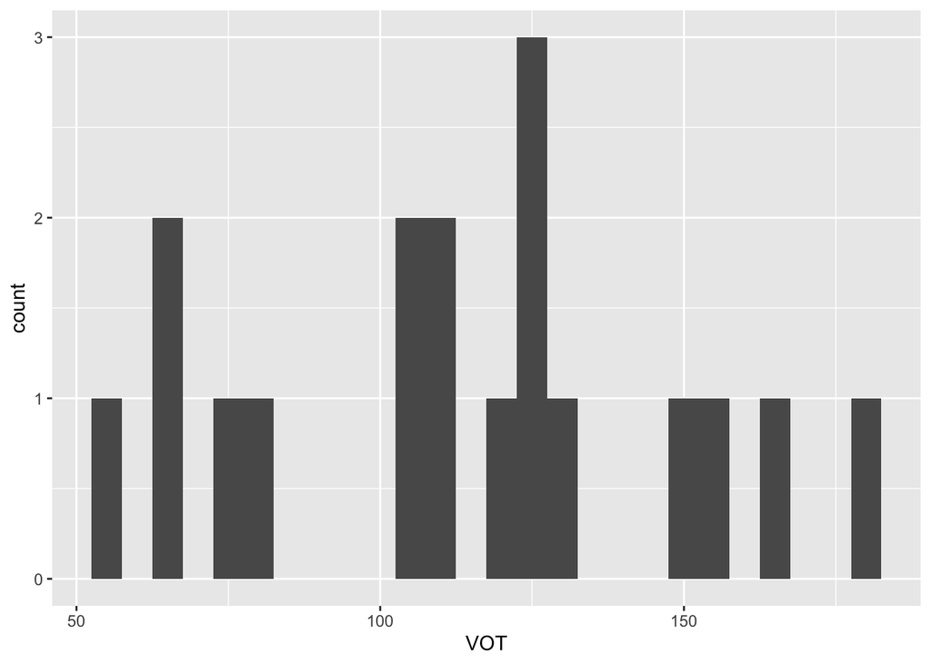

```r
ggplot(cherokee1971, aes(VOT))+geom_histogram(binwidth = 5)
```

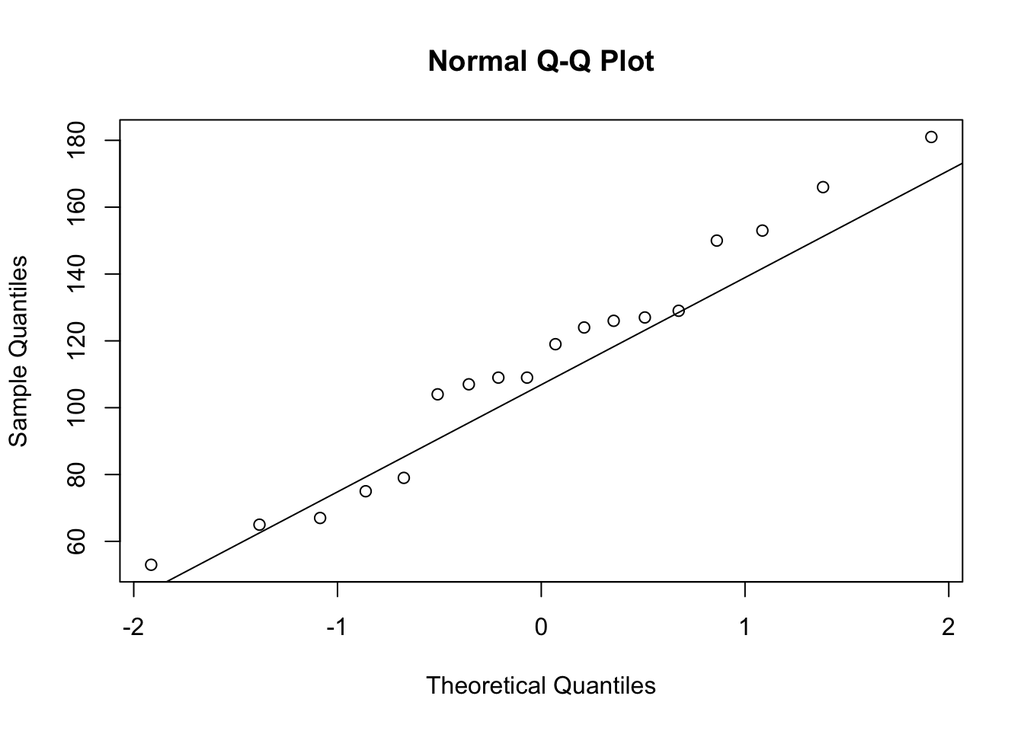

```r
qqnorm(cherokee1971$VOT)
qqline(cherokee1971$VOT)
```

The graph and histogram appear to have a approximately normal distribution for the 1971 cherokee dataset.

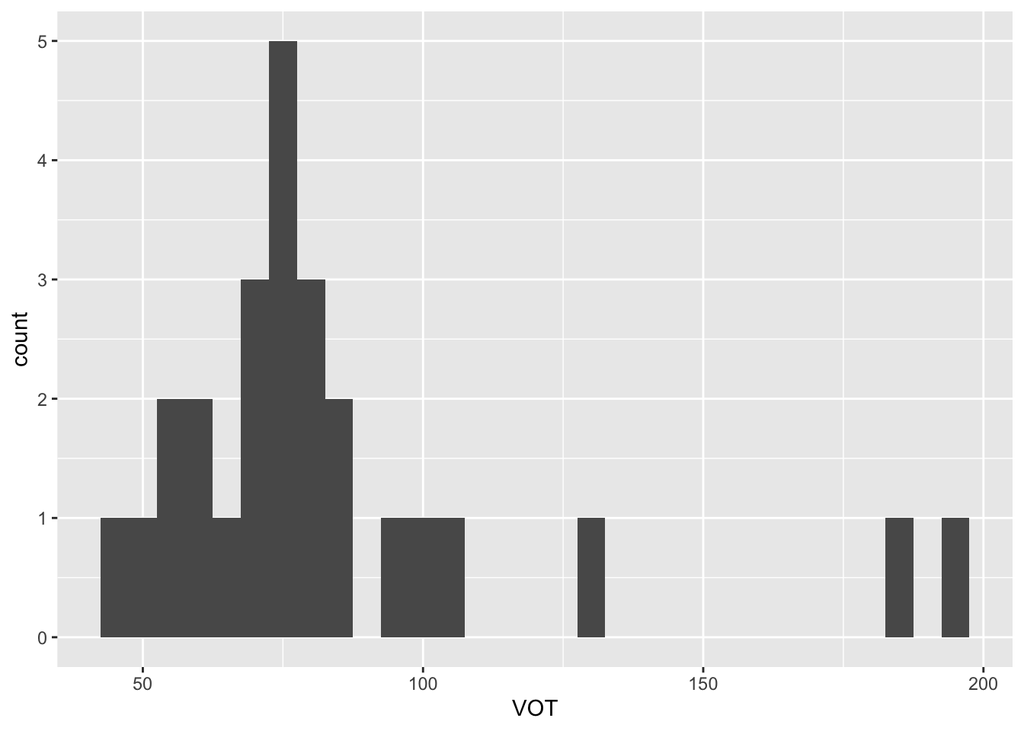

```r
ggplot(cherokee2001, aes(VOT))+geom_histogram(binwidth = 5)
```

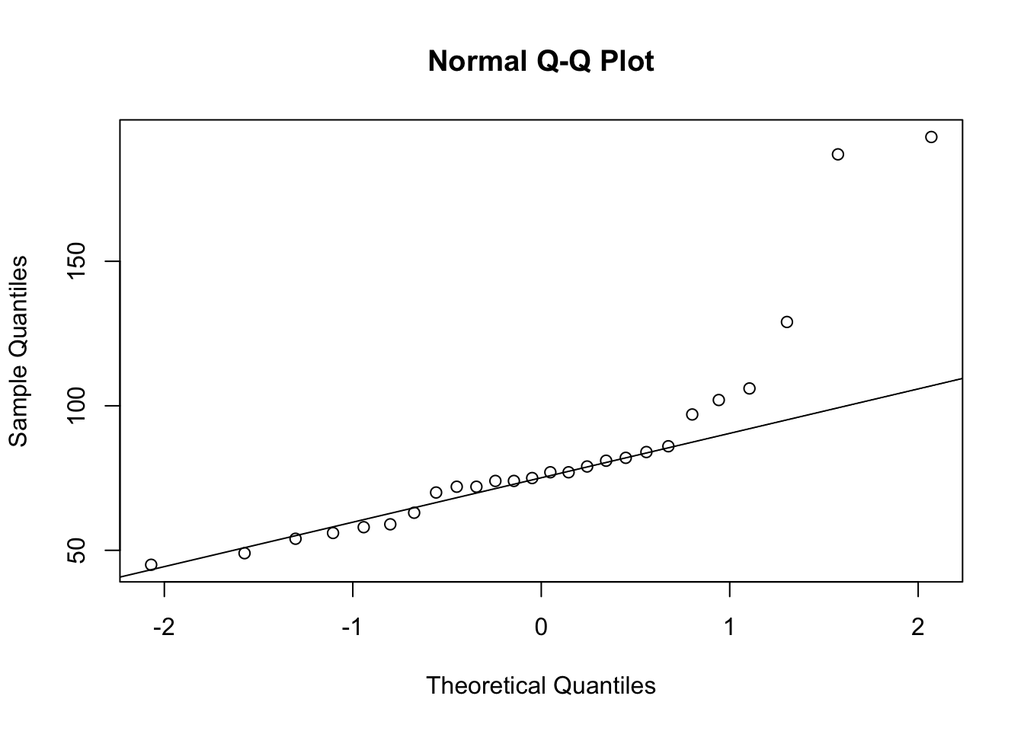

```r
qqnorm(cherokee2001$VOT)
qqline(cherokee2001$VOT)
```

The graph and histogram appear to be skewed right for the 2001 cherokee dataset. Therefore, to confirm our conclusion, we will use the two sample Wilcoxson rank-sum test.

```r
wilcox.test(VOT~year, cherokee)
```

```
##
##  Wilcoxon rank sum test with continuity correction
##
## data:  VOT by year
## W = 346.5, p-value = 0.007492
## alternative hypothesis: true location shift is not equal to 0
```

## More R visualization

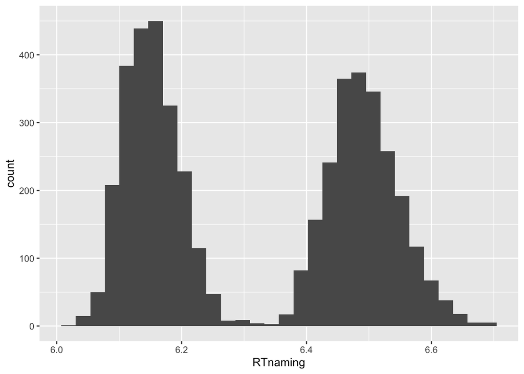

```r
eng = english
ggplot(eng, aes(RTnaming))+geom_histogram()
```

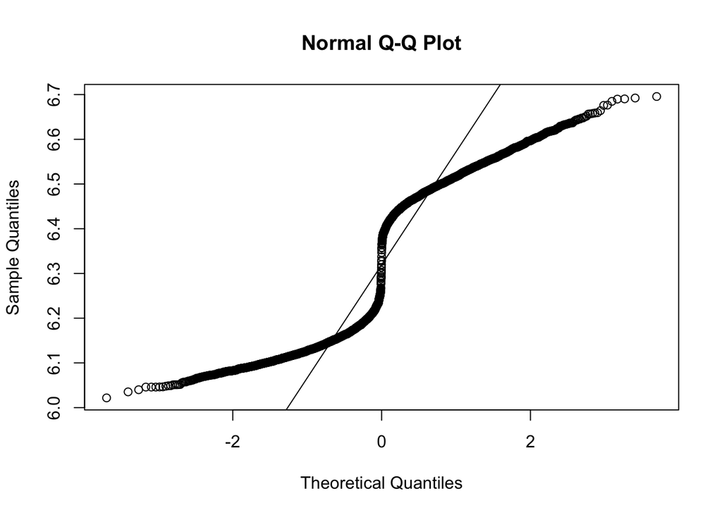

```r
qqnorm(eng$RTnaming)
qqline(eng$RTnaming)
```

The histogram shows a bimodal distribution. I believe it appears to be bimodal based on the fact of the two separate groups that may affect the distribution - young v.s. old participants. This can explain why the distribution is split in 2; one reflects the young participants’ reaction time, the other would reflect the old participants’ reaction time.

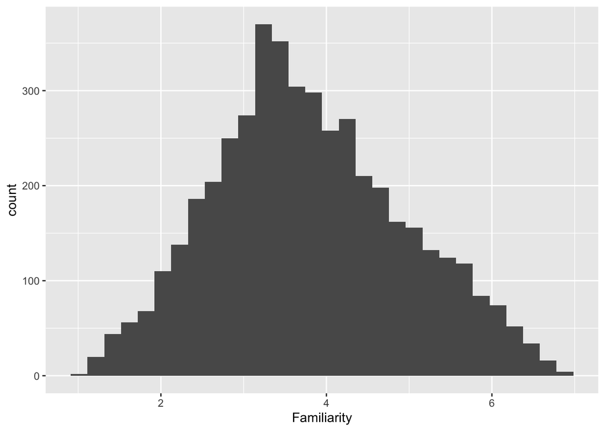

```r
ggplot(eng, aes(Familiarity))+geom_histogram()
```

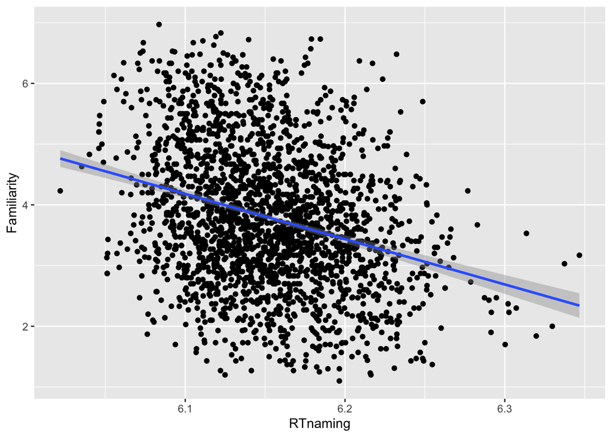

```r
ggplot(eng[eng$AgeSubject == 'young',], aes(RTnaming, Familiarity)) + geom_point() + geom_smooth(method = "lm")
```

There appears to be a negative correlation between the familiarity of the word and the word-naming reaction time. As young people’s familiarity with the word decreases, the reaction time in naming it increases. This makes sense, as it would take longer to recognize unfamiliar words.